# Part I - Ford GoBike System Data

## Introduction

The dataset reprepresents individual bike rides on a bike sharing Ford GoBike platform. All rides were made in a greater San Francisco Bay area. Overall, there are 16 columns present in the dataset. They denote general information on usage of the bikes such as duration of each ride, start and end time, and on customers such as customer type, their year of birth and gender. We may not use all of the columns, but rather focus on some of the features.

## Preliminary Wrangling

Before moving to the visualization part, we will perform some general clean-up of the data and try to look into the parts that may be a point of interest for the following visualizations.

```python
# import all packages and set plots to be embedded inline
import numpy as np
import pandas as pd
import matplotlib.pyplot as plt
import seaborn as sb

%matplotlib inline
```

```python
# loading the csv file with all the data
bike_sharing = pd.read_csv("fordgobike-tripdata.csv")
bike_sharing.head()
```

|  | duration_sec | start_time | end_time | start_station_id | start_station_name | start_station_latitude | start_station_longitude | end_station_id | end_station_name | end_station_latitude | end_station_longitude | bike_id | user_type | member_birth_year | member_gender | bike_share_for_all_trip |
| --- | --- | --- | --- | --- | --- | --- | --- | --- | --- | --- | --- | --- | --- | --- | --- | --- |
| 0 | 52185 | 2019-02-28 17:32:10.1450 | 2019-03-01 08:01:55.9750 | 21.0 | Montgomery St BART Station (Market St at 2nd St) | 37.789625 | -122.400811 | 13.0 | Commercial St at Montgomery St | 37.794231 | -122.402923 | 4902 | Customer | 1984.0 | Male | No |
| 1 | 42521 | 2019-02-28 18:53:21.7890 | 2019-03-01 06:42:03.0560 | 23.0 | The Embarcadero at Steuart St | 37.791464 | -122.391034 | 81.0 | Berry St at 4th St | 37.775880 | -122.393170 | 2535 | Customer | NaN | NaN | No |
| 2 | 61854 | 2019-02-28 12:13:13.2180 | 2019-03-01 05:24:08.1460 | 86.0 | Market St at Dolores St | 37.769305 | -122.426826 | 3.0 | Powell St BART Station (Market St at 4th St) | 37.786375 | -122.404904 | 5905 | Customer | 1972.0 | Male | No |
| 3 | 36490 | 2019-02-28 17:54:26.0100 | 2019-03-01 04:02:36.8420 | 375.0 | Grove St at Masonic Ave | 37.774836 | -122.446546 | 70.0 | Central Ave at Fell St | 37.773311 | -122.444293 | 6638 | Subscriber | 1989.0 | Other | No |
| 4 | 1585 | 2019-02-28 23:54:18.5490 | 2019-03-01 00:20:44.0740 | 7.0 | Frank H Ogawa Plaza | 37.804562 | -122.271738 | 222.0 | 10th Ave at E 15th St | 37.792714 | -122.248780 | 4898 | Subscriber | 1974.0 | Male | Yes |

```python
# checking the number of rows and columns
bike_sharing.shape
```

```
(183412, 16)
```

```python
# checking data types and potentially missing data
bike_sharing.info()
```

```
<class 'pandas.core.frame.DataFrame'>
RangeIndex: 183412 entries, 0 to 183411
Data columns (total 16 columns):
duration_sec               183412 non-null int64
start_time                 183412 non-null object
end_time                   183412 non-null object
start_station_id           183215 non-null float64
start_station_name         183215 non-null object
start_station_latitude     183412 non-null float64
start_station_longitude    183412 non-null float64
end_station_id             183215 non-null float64
end_station_name           183215 non-null object
end_station_latitude       183412 non-null float64
end_station_longitude      183412 non-null float64
bike_id                    183412 non-null int64
user_type                  183412 non-null object
member_birth_year          175147 non-null float64
member_gender              175147 non-null object
bike_share_for_all_trip    183412 non-null object
dtypes: float64(7), int64(2), object(7)
memory usage: 22.4+ MB
```

### Overview on the dataset

We can also see some data type discrepancies:

- 2) start_time, end_time are of dtype object, not datetime
- 3) start_station_id, end_station_id, bike_id, member_birth_year are of dtype float or int, though no arithmetic operations can be done on them
- 4) user_type, member_gender, bike_share_for_all_trip is of dtype object, not categorical

Do we need all columns?

- 5) latitude and longtitude measures are very specific values, we may not want to analyse them closely in this project

A few clean-up touches should be performed on this dataset.

### The main features of interest in the dataset

There are several interesting insights we can analyze in this dataset. It is great to have at least some information on the customers such as gender and year of birth. We could think about the following features:

- 1) What is the distribution of the genders in a dataset?
- 2) What is the distribution of the customers age?
- 3) Which gender is more likely to purchase/use Subscription? Of what age?

We can also analyze the features of the rides:

- 1) What is the distribution of the duration of each ride?
- 2) How does the duration of each ride depend on the gender of a user?
- 3) How does the duration of each ride depend on the age of a user?
- 4) How does the duration of each ride depend on the user type?

There might be more features to explore, we will add up more on the way. Re-iteration is good to see some new insights.

We will focus on the duration pre ride, member age, user type, and member gender feature. Possibly we will extend our list of feature during the process.

## Copy data before cleanup

```python
# copying before cleanup
df_bike_copy = bike_sharing.copy()
```

## Cleaning

We need to prepare the data for visualization. We will address the points from the overview section. Our data is rather tidy, so we will mostly work on the quality issues. To start, it is a good practice to first manage the missing data.

### Define

- 1) Remove rows with the missing data entries in start_station_id, start_station_name, end_station_id, end_station_name, and member_birth_year, member_gender.

Since there number of the missing data points is relatively low in proportion to a total number of the rows in the dataset, we can simply remove them.

### Code

```python
# removing missing data
df_bike_copy.dropna(subset = ['start_station_id', 'start_station_name', 'end_station_id', 'end_station_name', 'member_birth_year', 'member_gender'],
                    inplace = True)
```

### Test

```python
# all columns should be non-null
df_bike_copy.info()
```

```
<class 'pandas.core.frame.DataFrame'>
Int64Index: 174952 entries, 0 to 183411
Data columns (total 16 columns):
duration_sec               174952 non-null int64
start_time                 174952 non-null object
end_time                   174952 non-null object
start_station_id           174952 non-null float64
start_station_name         174952 non-null object
start_station_latitude     174952 non-null float64
start_station_longitude    174952 non-null float64
end_station_id             174952 non-null float64
end_station_name           174952 non-null object
end_station_latitude       174952 non-null float64
end_station_longitude      174952 non-null float64
bike_id                    174952 non-null int64
user_type                  174952 non-null object
member_birth_year          174952 non-null float64
member_gender              174952 non-null object
bike_share_for_all_trip    174952 non-null object
dtypes: float64(7), int64(2), object(7)
memory usage: 22.7+ MB
```

### Define

- 2) Tranform the member_birth_year into member_age

### Code

```python
# checking the latest year for the moment of the dataset creation
df_bike_copy['end_time'].max()
```

```
'2019-03-01 08:01:55.9750'
```

```python
# extracting member age
df_bike_copy['member_age'] = 2019 - df_bike_copy['member_birth_year']
```

### Define

- 3) Change dtype of start_time, end_time to datetime
- 4) Change dtype of start_station_id, end_station_id, bike_id, member_birth_year to strings
- 5) Change dtype of user_type, member_gender, bike_share_for_all_trip to categorical

### Code

```python
# cut off .0 for station ids and birth year, age
df_bike_copy['start_station_id'] = df_bike_copy['start_station_id'].astype(int)
df_bike_copy['end_station_id'] = df_bike_copy['end_station_id'].astype(int)
df_bike_copy['member_birth_year'] = df_bike_copy['member_birth_year'].astype(int)
df_bike_copy['member_age'] = df_bike_copy['member_age'].astype(int)
```

```python
# changing dtypes from object to datetime
df_bike_copy['start_time'] = pd.to_datetime(df_bike_copy['start_time'])
df_bike_copy['end_time'] = pd.to_datetime(df_bike_copy['end_time'])
```

```python
# changing dtypes from int/float to string
df_bike_copy['start_station_id'] = df_bike_copy['start_station_id'].astype(str)
df_bike_copy['end_station_id'] = df_bike_copy['end_station_id'].astype(str)
df_bike_copy['bike_id'] = df_bike_copy['bike_id'].astype(str)
df_bike_copy['member_birth_year'] = df_bike_copy['member_birth_year'].astype(str)
```

```python
# changing dtype from object to categorical
df_bike_copy['user_type'] = df_bike_copy['user_type'].astype('category')
df_bike_copy['member_gender'] = df_bike_copy['member_gender'].astype('category')
df_bike_copy['bike_share_for_all_trip'] = df_bike_copy['bike_share_for_all_trip'].astype('category')
```

### Test

```python
# checking that the dtypes were changed correctly
df_bike_copy.dtypes
```

```
duration_sec                        int64
start_time                 datetime64[ns]
end_time                   datetime64[ns]
start_station_id                   object
start_station_name                 object
start_station_latitude            float64
start_station_longitude           float64
end_station_id                     object
end_station_name                   object
end_station_latitude              float64
end_station_longitude             float64
bike_id                            object
user_type                        category
member_birth_year                  object
member_gender                    category
bike_share_for_all_trip          category
member_age                          int64
dtype: object
```

### Define

Since we do not plan to use geographical points in our visualization, we will remove them.

- 6) Remove start_station_latitude, start_station_longitude, end_station_latitude, end_station_longitude, member_birth_year columns

### Code

```python
# removing geo locations
df_bike_copy.drop(['start_station_latitude', 'start_station_longitude', 'end_station_latitude', 'end_station_longitude', 'member_birth_year'], axis = 1, inplace = True)
```

### Test

```python
# the columns were dropped
df_bike_copy.columns
```

```
Index(['duration_sec', 'start_time', 'end_time', 'start_station_id',
       'start_station_name', 'end_station_id', 'end_station_name', 'bike_id',
       'user_type', 'member_gender', 'bike_share_for_all_trip', 'member_age'],
      dtype='object')
```

The dataset is ready for visualisation. We will start with a univariate exploration of the features.

```python
df_bike_copy.describe()
```

|  | duration_sec | member_age |
| --- | --- | --- |
| count | 174952.000000 | 174952.000000 |
| mean | 704.002744 | 34.196865 |
| std | 1642.204905 | 10.118731 |
| min | 61.000000 | 18.000000 |
| 25% | 323.000000 | 27.000000 |
| 50% | 510.000000 | 32.000000 |
| 75% | 789.000000 | 39.000000 |
| max | 84548.000000 | 141.000000 |

## Univariate Exploration

In this section, we will focus on the exploration based on single variables.

To start, how long are the rides done via the platform?

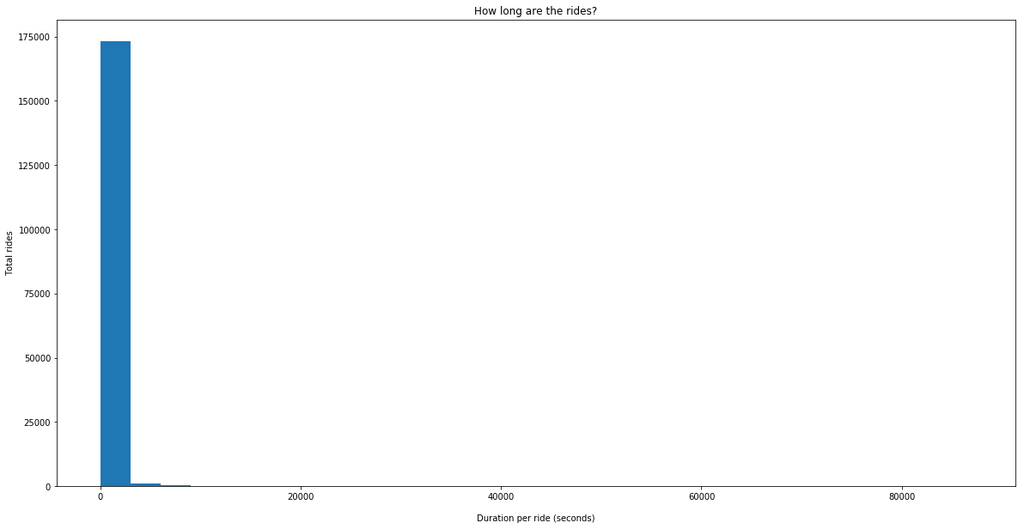

```python
# (Fig. 1)
# start with a distribution of duration of rides
plt.figure(figsize = [20, 10])
binsize = 3000
bins = np.arange(0, df_bike_copy['duration_sec'].max() + binsize, binsize)

plt.hist(data = df_bike_copy, x = 'duration_sec', bins = bins);
plt.title('How long are the rides?')
plt.xlabel('\nDuration per ride (seconds)')
plt.ylabel('Total rides')
plt.show()
```

The very first histogram is extremely right skewed. We cannot even see the right part with the current scale. It will be useful to analyze it in two parts. First, the left piece with the max at IQR3 (75%) and the right part with the outliers.

What is the general trend for most of the rides up to the third quantile (800 seconds)?

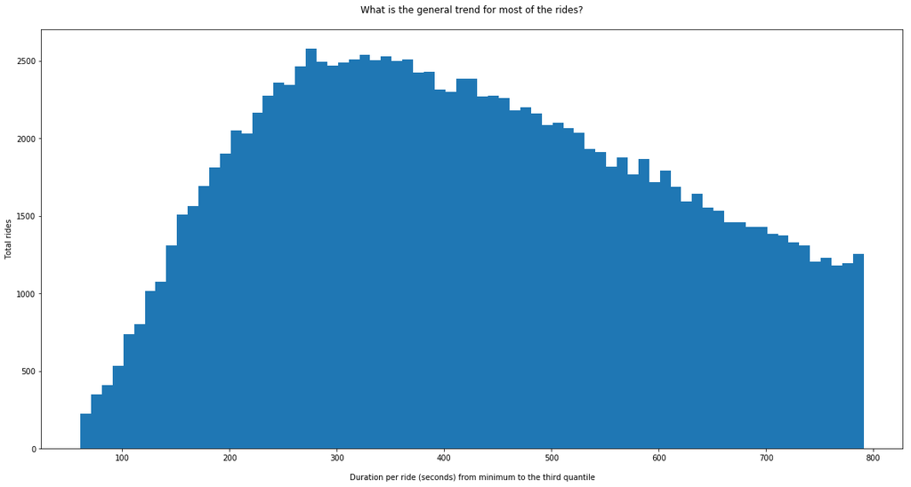

```python
# (Fig. 2)
# histogram for duration in seconds from min to IQR3
plt.figure(figsize = [20, 10])
binsize = 10
bins = np.arange(df_bike_copy['duration_sec'].min(), df_bike_copy['duration_sec'].quantile(0.75) + binsize, binsize)

plt.hist(data = df_bike_copy, x = 'duration_sec', bins = bins);
plt.title('What is the general trend for most of the rides?\n')
plt.xlabel('\nDuration per ride (seconds) from minimum to the third quantile')
plt.ylabel('Total rides')
plt.show()
```

We can see a more clear trend of the distribution of most rides. The peak is at around 280 seconds/ride (roughly 4,5 minutes/ride). In total there were around 2,600 rides of such duration. The overall distribution is mostly unimodal. Now we should also have a closer look at the outlier of the rightmost part of Fig.1.

How many relatively long rides (over 900 seconds or 15 minutes) were done?

```python
# checking how far is the maximum from other quantiles
df_bike_copy['duration_sec'].quantile(0.99)
```

```
3176.0
```

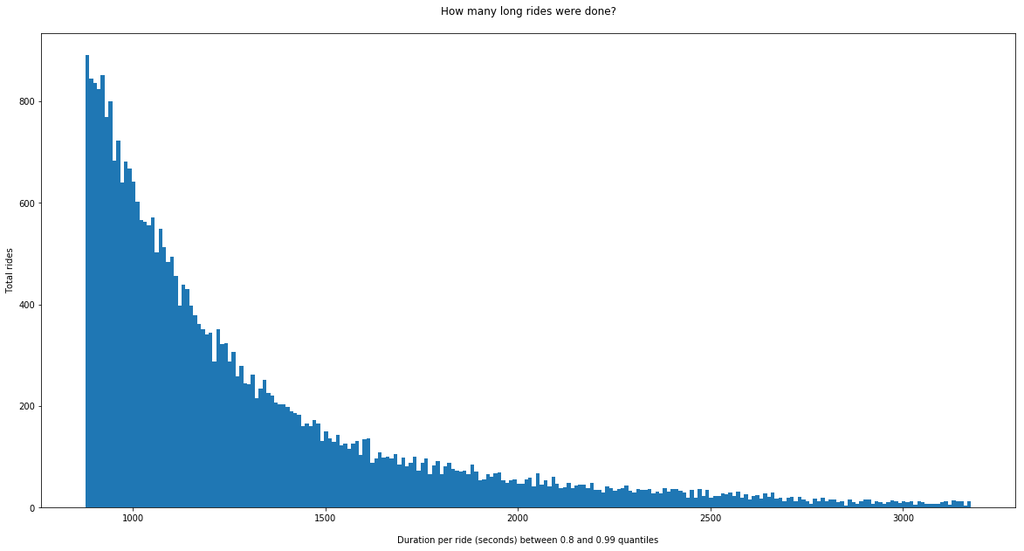

```python
# (Fig. 3)
# histogram for duration in seconds for the rightmost tiles
plt.figure(figsize = [20, 10])
binsize = 10
bins = np.arange(df_bike_copy['duration_sec'].quantile(0.8), df_bike_copy['duration_sec'].quantile(0.99) + binsize, binsize)

plt.hist(data = df_bike_copy, x = 'duration_sec', bins = bins);
plt.title('How many long rides were done?\n')
plt.xlabel('\nDuration per ride (seconds) between 0.8 and 0.99 quantiles')
plt.ylabel('Total rides')
plt.show()
```

Even after zooming into the rightmost outliers, we can still see a strongly right skewed histogram. The rightmost value is represented by a 0.99 quantile of the whole dataset for duration. The peak in this graph is the very first tile of around 900 rides. It is less than in Fig. 2, with a peak at 2,600 rides. We should analyze the max outlier.

```python
# checking the max outlier for duration
df_bike_copy['duration_sec'].max() / 60 / 60
```

```
23.485555555555557
```

The longest ride took around 23 hours... It is possibe some cycling enthusiast or even a professional sportswoman/sportsman did that fantastic trip and made us zoom into the dataset.

```python
# checking how many such enthusiasts there are
df_bike_copy.nlargest(10, 'duration_sec')
```

|  | duration_sec | start_time | end_time | start_station_id | start_station_name | end_station_id | end_station_name | bike_id | user_type | member_gender | bike_share_for_all_trip | member_age |
| --- | --- | --- | --- | --- | --- | --- | --- | --- | --- | --- | --- | --- |
| 85465 | 84548 | 2019-02-16 15:48:25.029 | 2019-02-17 15:17:33.080 | 3 | Powell St BART Station (Market St at 4th St) | 368 | Myrtle St at Polk St | 6301 | Subscriber | Male | No | 38 |
| 127999 | 83519 | 2019-02-09 15:16:17.537 | 2019-02-10 14:28:17.270 | 72 | Page St at Scott St | 43 | San Francisco Public Library (Grove St at Hyde... | 5561 | Customer | Male | No | 29 |
| 112435 | 83407 | 2019-02-11 16:25:33.069 | 2019-02-12 15:35:40.956 | 77 | 11th St at Natoma St | 344 | 16th St Depot | 1842 | Customer | Male | No | 31 |
| 5203 | 83195 | 2019-02-27 14:47:23.181 | 2019-02-28 13:53:58.433 | 243 | Bancroft Way at College Ave | 248 | Telegraph Ave at Ashby Ave | 5781 | Subscriber | Female | Yes | 57 |
| 95750 | 82512 | 2019-02-14 13:56:21.728 | 2019-02-15 12:51:34.315 | 368 | Myrtle St at Polk St | 44 | Civic Center/UN Plaza BART Station (Market St ... | 6152 | Customer | Other | No | 21 |
| 8631 | 81549 | 2019-02-27 09:41:38.552 | 2019-02-28 08:20:48.386 | 138 | Jersey St at Church St | 140 | Cesar Chavez St at Dolores St | 2266 | Subscriber | Female | No | 56 |
| 107581 | 79548 | 2019-02-12 17:45:50.536 | 2019-02-13 15:51:38.859 | 79 | 7th St at Brannan St | 66 | 3rd St at Townsend St | 1718 | Customer | Female | No | 24 |
| 90195 | 74408 | 2019-02-15 16:54:01.060 | 2019-02-16 13:34:09.367 | 3 | Powell St BART Station (Market St at 4th St) | 86 | Market St at Dolores St | 4714 | Subscriber | Male | No | 31 |
| 86454 | 74097 | 2019-02-16 16:20:41.465 | 2019-02-17 12:55:38.467 | 99 | Folsom St at 15th St | 139 | Garfield Square (25th St at Harrison St) | 6235 | Subscriber | Male | No | 39 |
| 123383 | 73930 | 2019-02-10 13:03:36.404 | 2019-02-11 09:35:46.446 | 270 | Ninth St at Heinz Ave | 270 | Ninth St at Heinz Ave | 1333 | Subscriber | Female | No | 30 |

Impressive! Some people were renting a bike for a very extended period of time (20+ hours). Let's have a look at the distribution of those outliers

```python
df_bike_copy.query('duration_sec > 10000').shape[0]
```

```
358
```

How many cycling enthusiasts are there?

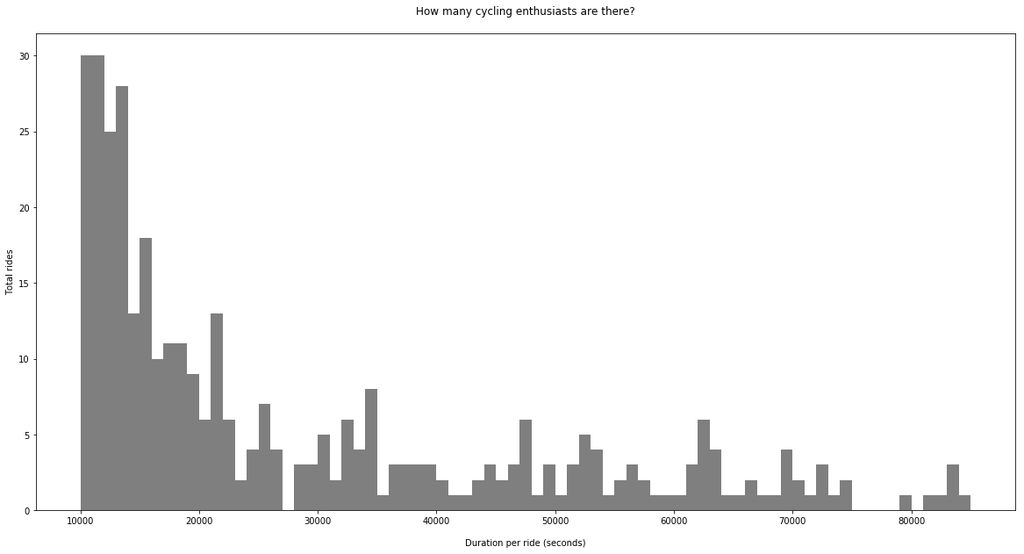

```python
# (Fig. 4)
# histogram for duration in seconds for the rightmost outliers
# choosing grey color to distinguish extreme outliers from the general trends
outlier_color = sb.color_palette()[7]

plt.figure(figsize = [20, 10])
binsize = 1000
bins = np.arange(10000, df_bike_copy['duration_sec'].max() + binsize, binsize)

plt.hist(data = df_bike_copy, x = 'duration_sec', bins = bins, color = outlier_color);
plt.title('How many cycling enthusiasts are there?\n');
plt.xlabel('\nDuration per ride (seconds)')
plt.ylabel('Total rides')
plt.show()
```

Indeed, not many people rented a bike for such a long time. We shall not forget, that the total number denotes the total number of rides that could be done by the same person in different times. We cannot check that since we do not have a unique user id to verify that. We could have used user age for this purpose, but it is not too precise, on top the users age and the counting can be incorrect.

Since the total number of rides with the duration > 3,000 seconds is low, we should only keep those with < 3,000 seconds to cancel the information noice. We could also save it into an outlier dataframe to analyze later on, but we want to focus on the general trend.

```python
# removing records with ride duration > 3,000
df_bike_copy = df_bike_copy.query('duration_sec < 3000')
```

Next, we will look into age distribution of the members.

How old are the bike riders of Ford GoBike?

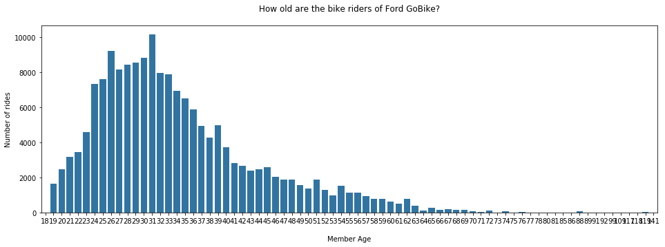

```python
# (Fig. 5)
# countplot for age distribution of the members
plt.figure(figsize = [16, 5])
base_color = sb.color_palette()[0]

sb.countplot(data = df_bike_copy,x = 'member_age', color = base_color)
plt.title('How old are the bike riders of Ford GoBike?\n')
plt.xlabel('\nMember Age')
plt.ylabel('Number of rides')
plt.show()
```

When analysing this graph, we shall not forget, that each row is a single ride. It is possible the same bike rider used the platform several times, thus their record is multiplied in the dataframe. Meaning that the same person could be depicted in the same age group (unless they celebrated a birthday in btween of the records).

Nevertheless, the countplot helps us to see a general trend of how old the platform users are. If we had another column with a unique user id, we could make a more precise countplot, by filtering out the rides of the same user and counting only unique rides.

The peak is at the age of 31. The second tallest plot is at the age of 26. The youngest biker is 18, possibly because it is the legal age when riding a bike is allowed in the USA, or because the platform users have to be at least 18 years old. Interestingly, 18 years olds barely used the platform, while starting from 19 years old, we can see significantly more users.

It's tough to make a judgement on the max age of the users, since it looks like some of the member_birth_year values were corrupted or possibly the users provided incorrect information or typed with typos.

We should zoom into the oldest bikers. How old are the oldest bike riders of Ford GoBike?

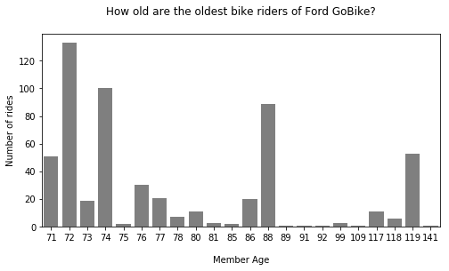

```python
# (Fig. 6)
# countplot for age distribution of the oldest members
# color palette is grey since we look into the outliers
plt.figure(figsize = (8, 4))
base_color = sb.color_palette()[0]
df_high_outliers_age = df_bike_copy.query('member_age > 70')

sb.countplot(data = df_high_outliers_age, x = 'member_age', color = outlier_color)
plt.title('How old are the oldest bike riders of Ford GoBike?\n')
plt.xlabel('\nMember Age')
plt.ylabel('Number of rides')
plt.show()
```

Indeed, looks like there were issues with some of the member_birth_year values that affected the member_age values. It is not feasible to have members aged 109, 117, ..., 141, unless the platform is so popular that the oldest citizens of the planet are using it. We can assume the cutoff for the age of members can be 91, since there are around 90 rides done by members aged 88, and almost none by members who are 89, 91, 92 years old. It is also remarkable to see around 135 rides done by users of 72 years old. That is what it means to stay in shape!

Since the total count for age groups older than 80 is small, we can remove those data points to eliminate information noice in further investigations.

```python
# removing records with member_age > 80
df_bike_copy = df_bike_copy.query('member_age < 80')
```

What type of users do we have?

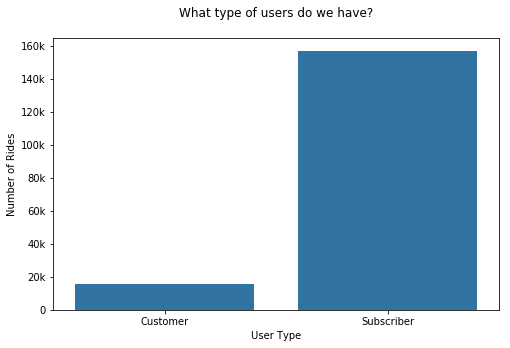

```python
# (Fig. 7)
# countplot on the types of members
plt.figure(figsize = [8, 5])

ax = sb.countplot(data = df_bike_copy, x = 'user_type', color = base_color);
ax.set(yticklabels = (['0', '20k', '40k', '60k', '80k', '100k', '120k', '140k', '160k']))
plt.title('What type of users do we have?\n')
plt.xlabel('User Type')
plt.ylabel('Number of Rides')
plt.show()
```

There are 2 types of members: Customer and Subscriber. Presumably, one type is on permanent membership, and another one is on the temporal case (uses the platform ocasionally or once).

We should also count the number of members per gender. Which genders are present in the dataset?

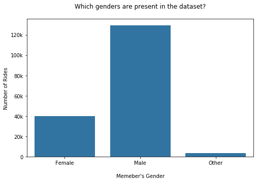

```python
# (Fig. 8)
# countplot on the genders
plt.figure(figsize = [8, 5])

ax = sb.countplot(data = df_bike_copy, x = 'member_gender', color = base_color);
ax.set(yticklabels = (['0', '20k', '40k', '60k', '80k', '100k', '120k']))
plt.title('Which genders are present in the dataset?\n')
plt.xlabel('\nMemeber\'s Gender')
plt.ylabel('Number of Rides')
plt.show()
```

The dataset has 3 genders: Females, Males, and Others. Males took the biggest number of rides via Fords GoBike (around 130,000 rides), Females did 40,000 rides, and Others did around 5,000 rides. We shall not forget, that the users are not denoted by unique ids, thus this countplot is just an accumulative representation of the rides. For example, the same person could have used the platform several times and has several records in the dataset.

### Adjustments of the data made

> Since the graphs for the duration of rides and age were extremely right skewed, we cut the data points with those extreme outliers. It will help to avoid noice in the next sections.

## Bivariate Exploration

In this section, we will explore the relationship between 2 different variables. To start, we will look into the relationship between age and duration of each ride. We want to answer the following questions: Which age category tends to cycle the longest and the shortest trips? What is the general trend between those 2 variables.

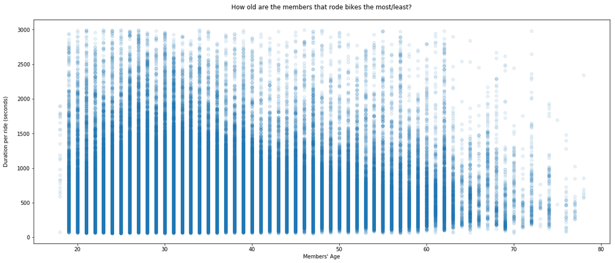

```python
# (Fig. 9)
# regplot to show the relationship between members' age and duration per ride
plt.figure(figsize = (20, 8))

sb.regplot(data = df_bike_copy, x = 'member_age', y = 'duration_sec', scatter_kws={'alpha':1/10}, fit_reg = False);
plt.title('How old are the members that rode bikes the most/least?\n');
plt.xlabel('Members\' Age');
plt.ylabel('Duration per ride (seconds)\n');
```

Even after using alpha to add transparency to avoid overlaps, we can only see a mere trend of older users taking shorter rides. To be precise, people older than 60 tend to take rides of around 1,200 seconds (20 min) or less. But to have a better representation of the trend, we can check the heatmap.

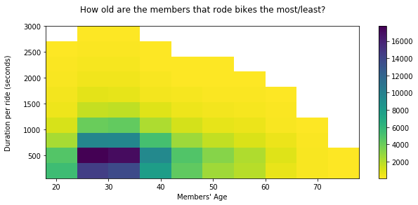

```python
# (Fig. 10)
# heatmap to show the relationship between members' age and duration per ride
# Use cmin to set a minimum bound of counts
# Use cmap to reverse the color map.
plt.figure(figsize = (10, 4))
plt.hist2d(data = df_bike_copy, x = 'member_age', y = 'duration_sec', cmin = 60, cmap = 'viridis_r')
plt.colorbar()
plt.title('How old are the members that rode bikes the most/least?\n');
plt.xlabel('Members\' Age');
plt.ylabel('Duration per ride (seconds)\n');
```

The heatmap helps us to see a clearer trend. Mostly users between their end 20s and early 30s cycle the longest, and members aged 60 and older take shorter rides.

Next, how does gender affect the duration of rides?

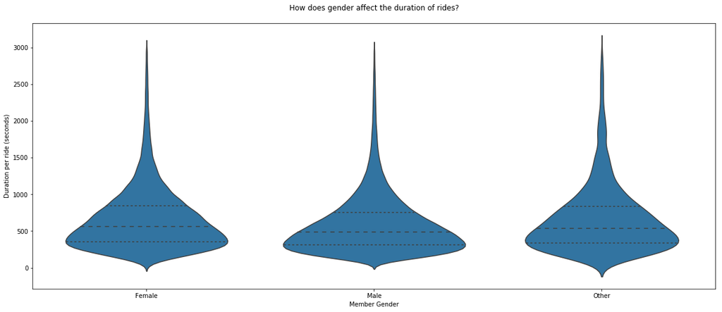

```python
# (Fig. 11)
# violin plot on member gender to ride duration
plt.figure(figsize = (20, 8))
sb.violinplot(data = df_bike_copy, x = 'member_gender', y = 'duration_sec', color = base_color, inner = 'quartile');
plt.title('How does gender affect the duration of rides?\n');
plt.xlabel('Member Gender');
plt.ylabel('Duration per ride (seconds)');
```

Interestingly, even though the total number of rides per each gender is significantly different, as we could see in the previous section above, the general trend for the duration of each ride is similar. Violin plots help us to see that the distribution on the duration per ride is very similar among all 3 genders. The mean is around 600 seconds (10 minutes), IQR1 is around 400 seconds (6-7 minutes), IQR3 is around 900 seconds (15 minutes). Even the distribution above IQR3 and below IQR1 is very much alike.

Gender does not affect the duration of each ride. In contrast, as seen above, age has a greater effect on it.

Since we have started looking into how gender affects the trend, we should check how likely is each gender to be a Subscriber?

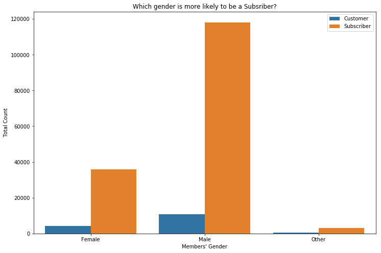

```python
# (Fig. 12)
# countplot on the gender to user type
plt.figure(figsize = (12, 8))

sb.countplot(data = df_bike_copy, x = 'member_gender', hue = 'user_type');
plt.title('Which gender is more likely to be a Subsriber?');
plt.xlabel('Members\' Gender');
plt.ylabel('Total Count');
plt.legend();
```

Since we have this interesting disproportion, I would like to have a closer look at the gender to duration per ride correlation again using faceting. I want to make a histogram for each gender in a separate graph next to each other.

How long was the trip depending on the gender of a user?

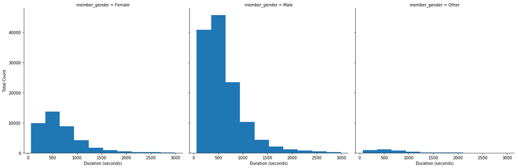

```python
# (Fig. 13)
# faceting on gender vs. duration per ride
g = sb.FacetGrid(data = df_bike_copy, col = 'member_gender', col_wrap = 3, size = 6);
g.map(plt.hist, "duration_sec");
g.set_xlabels('Duration (seconds)');
g.set_ylabels('Total Count');
```

Just like in the violin plots above, we see that the peaks for all genders is around 450-550 seconds. Faceting helps us to see the rightmost data points better. We can see that Males had more records with longer duration above 2,000 seconds compared to Females and Others. At the same time, Males had 40,000 records for a duration of below 450 seconds, meaning that Males are also likely to rent a bike for some short trips. That is a new insight.

### The relationships observed in this part of the investigation.

> The relationship between the age of a member and duration per ride showed us that a group of members in their end 20s and early 30s are the most frequent users of the platform and also tend to take the longest rides across all other age groups. We also identified that this frequency goes down with an age up to 60 years old, then we see a drop in activity. Meaning the users in their 60s and older are less active users.

> We also checked how gender affects the duration per ride. In general, there are more Male users on the platform, Females are the second most frequesnt users, and Others are the least. When analysing the trend we should remember this fact. Interestingly, the trend is rather similar among all 3 genders: the most often duration per ride is around 600 seconds (10 minutes). While among the longest rides of more than 2,000 seconds the Males stand out the most.

## Multivariate Exploration

> In the final section, we want to check the relationships between the variables we have already analyzed in the Univariate and Bivariate Exploration sections. We will present 2 Multivariate exploration visualizations.

> How long was each ride for female/male/other members of different user types?

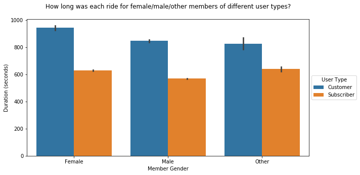

```python
plt.figure(figsize = [10, 5])

ax = sb.barplot(data = df_bike_copy, x = 'member_gender', y = 'duration_sec', hue = 'user_type');
plt.title('How long was each ride for female/male/other members of different user types?\n')
plt.xlabel('Member Gender')
plt.ylabel('Duration (seconds)')
ax.legend(loc = 'center left', bbox_to_anchor = (1, 0.5), title = 'User Type');
```

That is something new. By comparing categorical variables vs. numeric variable we see some new insights. If previously, we saw that Males are frequent users of the platfrom in general, and they tend to go for a Subscription, now we see that Female Subsribers tend to take longer rides (around 610 seconds or around 10 minutes) compared to Males (less than 600 seconds or 10 minutes), and Others tend to take even more longer rides in this membership type (more than 610 seconds or more than 11 minutes).

Another point of interest, even though there are more Male Customers, Female Customers take longer rides (above 900 seconds or above 15 minutes) compared to everyone else.

Finally, we want to see how all 3 variables related to users are applied with each other.

Who are the users of Ford GoBike platform? What is the distribution among their age, gender and user type?

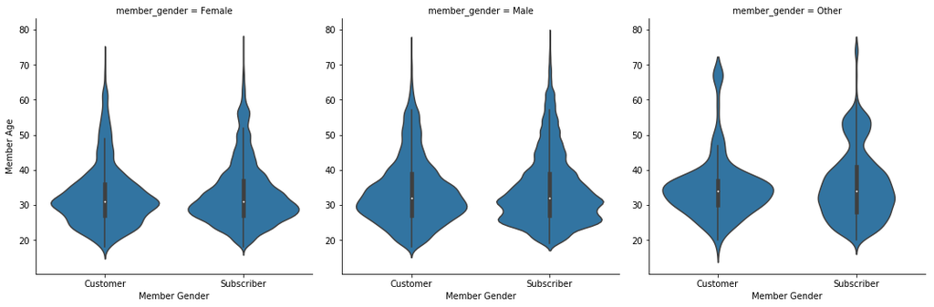

```python
# (Fig. 15)
# faceting on info about the users
plt.figure(figsize = [10, 5])
g = sb.FacetGrid(data = df_bike_copy, col = 'member_gender', size = 5);
g.map(sb.violinplot, 'user_type', 'member_age');
g.set_xlabels('Member Gender');
g.set_ylabels('Member Age');
```

The overall trend prevails among all groups, but here are a few points worth mentioning. First, we see a strange dip in Male Subscriber violin for an age category in between 25 and 30 years old. In contrast, Females and others are more persistent in that age group for the same Subsriber category, in fact, it's the most active age group. It shows that Males between 25 and 30 years old who presumably purchased Subsription, use it less often.

However, we also see that Male Customers over 45 years old are rather consistent in their cycling routine.

Others have rather special violin plots for both user types. Other Customers have the most users in the age category of around 35 years old, what is 5 years older compared to Males and Females. Others have very few Customers in their 50s and then there is a spike for the users of 60 plus. At the same time, Other Subsribers have more users in their 50s and almost none 60 plus.

## Conclusions

> In the second part Bivariate Exploration, we derived reationships among the values explored in the first part. While we previously found out that the users in their end 20s and early 30s are the most frequent users, they also contribute to the longest rides. The users aged 60 plus spent signficantly less time cycling. In general, gender does not affect the duration of each ride. However, Males contribute the most to the longest rides. For user types, a preference to be a Subscriber is prevailed among all 3 genders. But Males tend to be a Subscriber way more compared to other two genders.